# Lab 1

Lucas Street, 1874989

```python
%matplotlib inline
import matplotlib
import matplotlib.pyplot as plt
matplotlib.rc('font', size=22)
matplotlib.rc('figure', figsize=(18, 10))

import numpy as np
import pandas as pd
from scipy import stats
```

## Standard Normal Distribution, μ=0, σ=1

Before we talk about the standard normal distribution, a general *Gaussian* distribution is of the form $f(x) = \frac{1}{\sqrt{2\pi\sigma^2}} e^{-\frac{(x-\mu)^2}{2\sigma^2}}$, for mean value $\mu$ and standard deviation $\sigma$.

The standard normal distribution is the Gaussian distribution of a random variable of mean $\mu=0$ and standard deviation $\sigma=1$. When a value lies outside the mean, the distance from the mean to the value can be expressed as a multiple of the standard deviation, usually called the "z-score". Thus a value with a "z-score of 2" or one that lies "2 sigma" from the mean corresponds to the point located $2\sigma$ from $\mu$.

The probability that a number from the distribution lies within a particular range of z-scores is found by integrating the Gaussian function from one z-score to the other. For example, the probability that a value lies $1\sigma$ from the mean is the integral of the standard normal probability density function (PDF) from -1 to 1. Similarly, since the integral over the entire PDF is equal to 1, the probability that a value lies within $-\infty\sigma$ to $+\infty\sigma$ is 100%.

Integrating Gaussian PDFs is usually not a pleasant task, so values for various z-scores have been tabulated. The following is a Z table for the standard normal distribution, which gives the probability that a value may lie between 0 and z. The far left column is the larger portion of the z-score, and the upper row is the smaller portion. To find the probability that a value lies within 0 and 0.75, for example, we locate the element of the table at row 8 (0.7), column 6 (0.05), which is 0.27337. Thus the probability is about 27%.

| z | +0.00 | +0.01 | +0.02 | +0.03 | +0.04 | +0.05 | +0.06 | +0.07 | +0.08 | +0.09 |
| --- | --- | --- | --- | --- | --- | --- | --- | --- | --- | --- |
| 0.0 | 0.00000 | 0.00399 | 0.00798 | 0.01197 | 0.01595 | 0.01994 | 0.02392 | 0.02790 | 0.03188 | 0.03586 |
| 0.1 | 0.03983 | 0.04380 | 0.04776 | 0.05172 | 0.05567 | 0.05962 | 0.06356 | 0.06749 | 0.07142 | 0.07535 |
| 0.2 | 0.07926 | 0.08317 | 0.08706 | 0.09095 | 0.09483 | 0.09871 | 0.10257 | 0.10642 | 0.11026 | 0.11409 |
| 0.3 | 0.11791 | 0.12172 | 0.12552 | 0.12930 | 0.13307 | 0.13683 | 0.14058 | 0.14431 | 0.14803 | 0.15173 |
| 0.4 | 0.15542 | 0.15910 | 0.16276 | 0.16640 | 0.17003 | 0.17364 | 0.17724 | 0.18082 | 0.18439 | 0.18793 |
| 0.5 | 0.19146 | 0.19497 | 0.19847 | 0.20194 | 0.20540 | 0.20884 | 0.21226 | 0.21566 | 0.21904 | 0.22240 |
| 0.6 | 0.22575 | 0.22907 | 0.23237 | 0.23565 | 0.23891 | 0.24215 | 0.24537 | 0.24857 | 0.25175 | 0.25490 |
| 0.7 | 0.25804 | 0.26115 | 0.26424 | 0.26730 | 0.27035 | 0.27337 | 0.27637 | 0.27935 | 0.28230 | 0.28524 |
| 0.8 | 0.28814 | 0.29103 | 0.29389 | 0.29673 | 0.29955 | 0.30234 | 0.30511 | 0.30785 | 0.31057 | 0.31327 |
| 0.9 | 0.31594 | 0.31859 | 0.32121 | 0.32381 | 0.32639 | 0.32894 | 0.33147 | 0.33398 | 0.33646 | 0.33891 |
| 1.0 | 0.34134 | 0.34375 | 0.34614 | 0.34849 | 0.35083 | 0.35314 | 0.35543 | 0.35769 | 0.35993 | 0.36214 |

Source: https://en.wikipedia.org/wiki/Standard_normal_table

Let's replicate this table with Python. SciPy provides us with a *cumulative distribution function* `cdf` that integrates the PDF from $-\infty$ to z. Since we want to integrate from 0 to z, we subtract the integral over $-\infty$ to 0 from the integral over $-\infty$ to z.

```python
large_increments = np.linspace(0, 1, 11)
small_increments = np.linspace(0, 0.09, 10)
table = np.zeros((len(large_increments), len(small_increments)))

for i in range(len(large_increments)):
    for j in range(len(small_increments)):
        table[i][j] = stats.norm.cdf(large_increments[i] + small_increments[j]) - stats.norm.cdf(0)

pd.DataFrame(table, columns=small_increments, index=large_increments)
```

|  | 0.00 | 0.01 | 0.02 | 0.03 | 0.04 | 0.05 | 0.06 | 0.07 | 0.08 | 0.09 |
| --- | --- | --- | --- | --- | --- | --- | --- | --- | --- | --- |
| 0.0 | 0.000000 | 0.003989 | 0.007978 | 0.011966 | 0.015953 | 0.019939 | 0.023922 | 0.027903 | 0.031881 | 0.035856 |
| 0.1 | 0.039828 | 0.043795 | 0.047758 | 0.051717 | 0.055670 | 0.059618 | 0.063559 | 0.067495 | 0.071424 | 0.075345 |
| 0.2 | 0.079260 | 0.083166 | 0.087064 | 0.090954 | 0.094835 | 0.098706 | 0.102568 | 0.106420 | 0.110261 | 0.114092 |
| 0.3 | 0.117911 | 0.121720 | 0.125516 | 0.129300 | 0.133072 | 0.136831 | 0.140576 | 0.144309 | 0.148027 | 0.151732 |
| 0.4 | 0.155422 | 0.159097 | 0.162757 | 0.166402 | 0.170031 | 0.173645 | 0.177242 | 0.180822 | 0.184386 | 0.187933 |
| 0.5 | 0.191462 | 0.194974 | 0.198468 | 0.201944 | 0.205401 | 0.208840 | 0.212260 | 0.215661 | 0.219043 | 0.222405 |
| 0.6 | 0.225747 | 0.229069 | 0.232371 | 0.235653 | 0.238914 | 0.242154 | 0.245373 | 0.248571 | 0.251748 | 0.254903 |
| 0.7 | 0.258036 | 0.261148 | 0.264238 | 0.267305 | 0.270350 | 0.273373 | 0.276373 | 0.279350 | 0.282305 | 0.285236 |
| 0.8 | 0.288145 | 0.291030 | 0.293892 | 0.296731 | 0.299546 | 0.302337 | 0.305105 | 0.307850 | 0.310570 | 0.313267 |
| 0.9 | 0.315940 | 0.318589 | 0.321214 | 0.323814 | 0.326391 | 0.328944 | 0.331472 | 0.333977 | 0.336457 | 0.338913 |
| 1.0 | 0.341345 | 0.343752 | 0.346136 | 0.348495 | 0.350830 | 0.353141 | 0.355428 | 0.357690 | 0.359929 | 0.362143 |

Now let's convert probabilities to the form $X\sigma$. The probability that a value lies at least $1\sigma$ to the left of the mean is about 0.1587, for $2\sigma$ away it's 0.0227, and for $5\sigma$ away it's 2.8665*10<sup>-7</sup>. To find the z-score of these probabilities, we use the *percent-point function* `ppf`, which integrates the PDF from $-\infty$ to whatever value gives us the desired probability.

```python
probabilities = np.array([0.1587, 0.0227, 2.8665e-07])
print(stats.norm.ppf(probabilities))
```

```
[-0.99981509 -2.00092939 -5.00000106]
```

Great - these are approximately $1\sigma$, $2\sigma$, and $5\sigma$, as expected. The negative sign on each value indicates that it falls to the left of the mean (which is at 0). Since we're integrating the PDF starting at $-\infty$, we expect to end up on the left of the mean as long as the desired probability is less than 0.5.

## Chi-Squared distribution, k=10

The chi-squared distribution is the sum of the squares of standard normal random variables. A value $A$ in the chi-squared distribution is equal to $\sum\limits_{i=1}^{k} Z_i^2$, where $Z_i$ is the $i^{th}$ standard-normally distributed variable, and $k$ is the number of *degrees of freedom*, which specify how many terms define the distribution.

First, let's plot a histogram of some chi-squared distributed data, as well as the PDF for the distribution. We'll define our distribution using the parameter $k=10$.

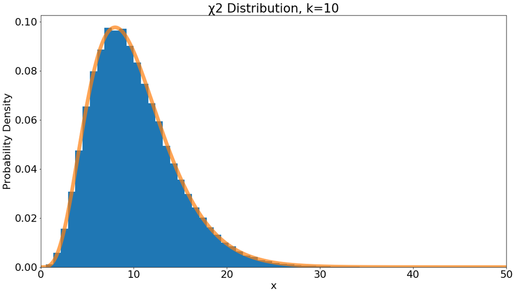

```python
dist = stats.chi2(10)
samples = dist.rvs(100_000)

plt.title("χ2 Distribution, k=10")
plt.xlabel("x")
plt.ylabel("Probability Density")
plt.hist(samples, 50, density=True)
plt.xlim([0, 50])
x = np.linspace(0, 50, 1000)
plt.plot(x, dist.pdf(x), linewidth = 8, alpha = 0.7);
```

Now let's examine what it means to find a probability of $X\sigma$ when our data is not Gaussian.

Consider the case of a measurement of some quantity where one may either receive a signal or receive no signal. Let's choose an arbitrary signal threshold for this hypothetical measurement: 10. Thus, a measurement that has the value 10 can be considered "signal-like", with a value less than 10 it is "not signal-like", and with a value greater than 10 it is "more signal-like". Now we can ask a statistical question about the probability of finding a signal in some supposedly signal-free background data:

Given that our signal-free data is chi-squared distributed, what is the probability that we find a value that is as signal-like or more signal-like than 10 in the signal-free data?

We must integrate the PDF for the distribution: $P = \int\limits_{10}^{\infty} \frac{1}{2^{k/2}\Gamma({k/2})}x^{k/2 - 1}e^{-x/2}$ with $k=10$.

The CDF will integrate the distribution from $-\infty$ to some $z$. Since we want to integrate from 10 to $\infty$, we can use something called the *survival function* instead, which is defined to be one minus the CDF (that is, it integrates the PDF from z to $\infty$).

```python
dist.sf(10)
```

```
0.44049328506521257
```

This probability is about 44%, in other words, it's fairly likely our background produced an erroneous signal. Let's convert it to the form $X\sigma$ using the `ppf` function.

```python
stats.norm.ppf(dist.sf(10))
```

```
-0.14971867956893092
```

Notice that we're calling the `ppf` function on the *standard normal distribution*, NOT our chi-squared distribution. When we put this probability in the form $X\sigma$, what we really mean is the same probability as if our data were Gaussian. Integrating from $-\infty$ to -0.14971867956893092 (or, equivalently, from 0.14971867956893092 to $\infty$) on a standard normal PDF gives us the *same* probability as integrating our chi-squared PDF from 10 to $\infty$.

Therefore, the probability that we measure a value that is as signal-like or more signal-like than 10 in the signal-free data is said to be $0.15\sigma$.

Let's keep increasing the threshold for what constitutes a signal. This should make the resulting probability drop, and the number of $\sigma$'s should increase, since we will end up further from the mean.

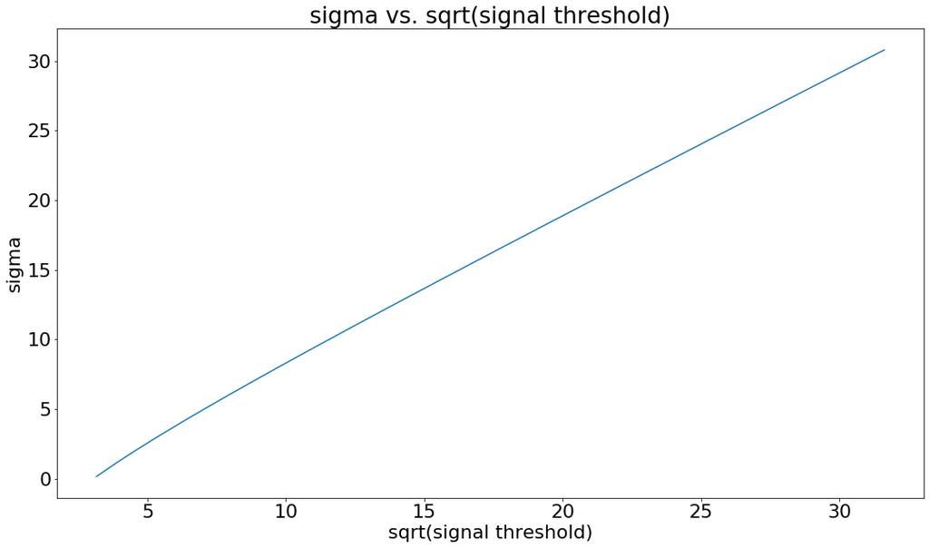

```python
signals = np.linspace(10, 1000, 200)
sigmas = np.abs(stats.norm.ppf(dist.sf(signals)))

plt.title("sigma vs. sqrt(signal threshold)")
plt.xlabel("sqrt(signal threshold)")
plt.ylabel("sigma")
plt.plot(np.sqrt(signals), sigmas);
```

This plot tells us that the probability (expressed as $X\sigma$) of finding a data point that is as signal-like or more signal-like than some signal threshold is linearly related to the square root of the threshold. This makes sense, because the square root of a chi-squared distribution looks like a normal distribution. The above relationship is linear because a normally-distributed signal that is twice as far away from the mean will have a z-score that is twice as large.

## Binomial Distribution

The binomial distribution is a discrete distribution, frequently used to model the probability of some "success" for $n$ independent trials, where success is some boolean value. Examples range widely from flipping a coin to statistical mechanics. The binomial distribution gives us a *probability mass function* that we can use to calculate the probability of some number of successes $k$ in $n$ trials, where $p$ is the probability of success for any given trial.

Let's use the coin-flipping example, since it's relatively simple. Let's say we flip a coin 10 times, and each independent trial has a 0.5 probability of landing heads or tails. Since the probability for either outcome is the same, we'll arbitrarily define "success" to mean we landed on heads.

```python
def plot_coinflips(num_flips, p=0.5, width=5):
    dist = stats.binom(num_flips, p)
    num_successes = np.arange(0, num_flips + 1)
    plt.title(f"Probability of k heads for {num_flips} coin flips")
    plt.xlabel("Number of heads, k")
    plt.ylabel("Probability Mass")
    plt.vlines(num_successes, 0, dist.pmf(num_successes), linewidth=width)
    plt.xlim(0, num_flips)
    plt.ylim(0, None)
```

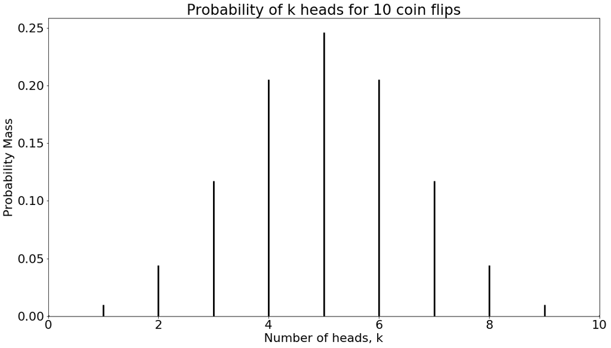

```python
plot_coinflips(10, width=3)
```

From the plot, it *looks* like we have the greatest chance of getting 5 heads with 10 coin flips, but there's an important subtlety about this plot to keep in mind. Each point on the above graph indicates the *probability mass* of the value $k$. This isn't a *probability* in the sense we might be thinking of - to get a probability like we got from the continuous chi-squared distribution, we must sum all the probability masses of each value of $k$ up to our desired value (analogous to the integral of the continuous PDF) in a way that answers the statistical question. This is because if we get 10 heads, we have also gotten 9 heads, and 8 heads, and so on. The precise question we're asking in this case is "What is the probability of getting *at most* $k$ successes for $n$ trials?"

Let's sum up the probability masses for all values up to and including 5 and see if we get 0.5. We'll use the `pmf` function to get the probability masses.

```python
sum(stats.binom.pmf(np.arange(0, 6), 10, 0.5))
```

```
0.6230468750000006
```

Not quite. What if we flip the coin 10,000 times and sum up to 5,000 successes?

```python
sum(stats.binom.pmf(np.arange(0, 5001), 10_000, 0.5))
```

```
0.5039893230694178
```

That's more like it. What's going on here? Let's plot a few more versions of the binomial distribution with varying numbers of coin flips.

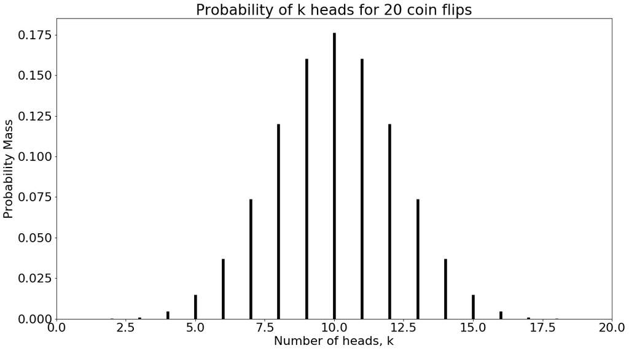

```python
plot_coinflips(20)
```

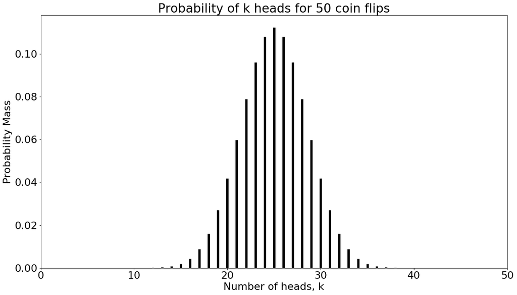

```python
plot_coinflips(50)
```

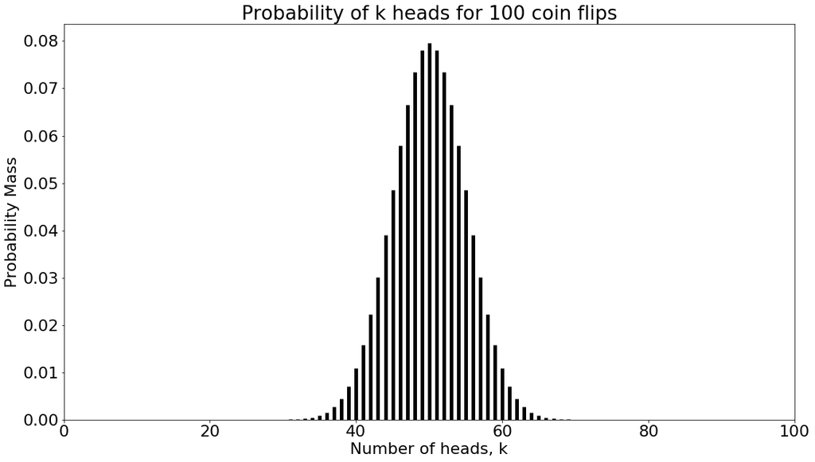

```python
plot_coinflips(100)
```

Interesting. These plots seem to be describing Gaussian-like distributions with a mean equal to half the number of trials. It turns out that this distribution does approach a Gaussian distribution as the number of trials $n$ approaches $\infty$. As a result, when we sum the probability masses up to the central value, we're approximating an integral to the center of the standard normal distribution, which approximates 0.5.

What if our coin is weighted so that it falls on heads more often than it falls on tails? Let's say we now have a 60% chance of landing on heads - our value for $p$ is 0.60.

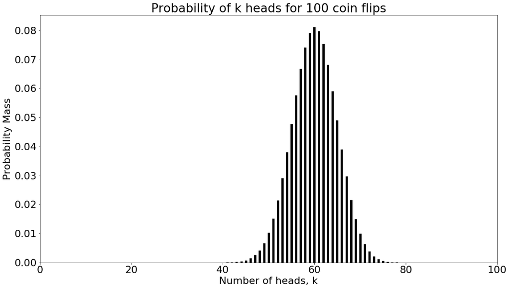

```python
plot_coinflips(100, p=0.60)
```

The distribution has shifted - in other words the "mean" of the approximate Gaussian distribution has increased to 60 heads out of 100 tosses, 60% of the total number of trials.

Now what is the probability we will get at most 50 heads?

```python
sum(stats.binom.pmf(np.arange(0, 51), 100, 0.60))
```

```
0.027099197757008548
```

Only about 2.71%. Let's associate this probability with a value of the form $X\sigma$.

```python
stats.norm.ppf(0.027099197757008548)
```

```
-1.925247553401777
```

This is $1.93\sigma$. Since that's located fairly far away from the mean of a standard normal PDF, we're integrating much less than half of the total PDF, giving us about 0.0271. For each discrete value of $k$ that we pick, we'll get a discrete probability and thus a discrete $X\sigma$ value. Note that the mean of our approximate Gaussian distribution can be anything - it only appears to depend on the probability of success. Therefore, for 1000 coin flips, if we set $p$ to the value 0.6005, it would be about equally as likely to get 600 heads as it would to get 601, since the mean would be at 600.5. Let's test this theory:

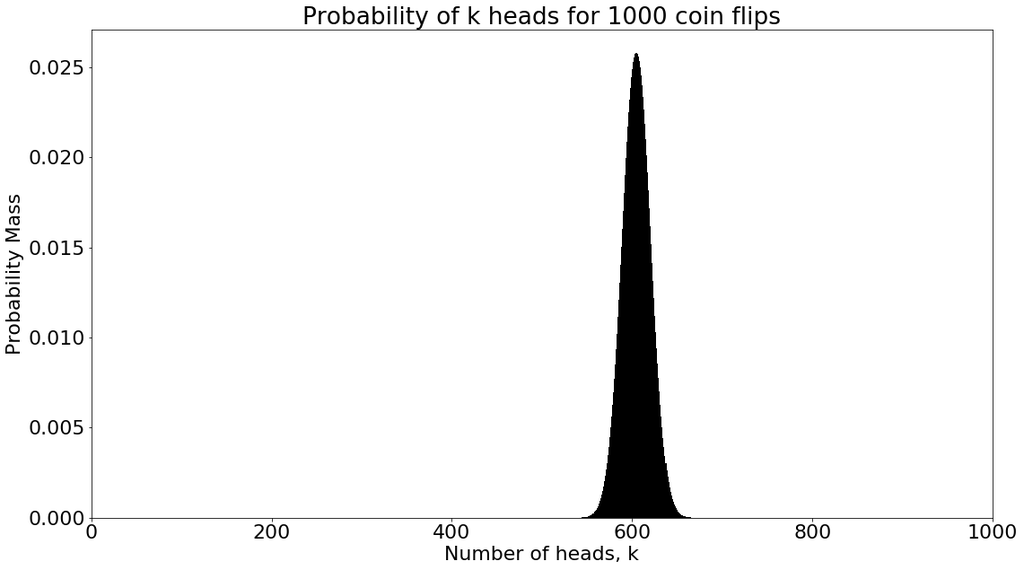

```python
plot_coinflips(1000, p=0.605, width=2)
```

```python
prob_600 = sum(stats.binom.pmf(np.arange(0, 601), 1000, 0.6005))
prob_601 = sum(stats.binom.pmf(np.arange(0, 602), 1000, 0.6005))
print(f"Prob for 600: {prob_600}, Prob for 601: {prob_601}")
```

```
Prob for 600: 0.49913673615504106, Prob for 601: 0.5248789165196933
```

Close enough. It's not perfect, but that's because we're only doing 1000 coin flips. If we try it with 10,000 flips and $p = 0.60005$, however:

```python
prob_6000 = sum(stats.binom.pmf(np.arange(0, 6001), 10000, 0.60005))
prob_6001 = sum(stats.binom.pmf(np.arange(0, 6002), 10000, 0.60005))
print(f"Prob for 6000: {prob_6000}, Prob for 6001: {prob_6001}")
print(f"Difference of only {abs(prob_6000 - prob_6001)}")
```

```
Prob for 6000: 0.49972840004294544, Prob for 6001: 0.5078714756621423
Difference of only 0.00814307561919686
```

The probability of getting 6000 and of getting 6001 is much closer, as we expected.